# JupyterNoteboookMetaplasiaClassification

[figure not shown]

voltar

### Projeto Final

#### Unidade Curricular: Deep Learning

##### Tema: Metaplasia classification in endoscopy images

##### Docentes: António Cunha, Paulo Pombinho e Pedro Mestre

##### Discente: Ivo Nunes nº 2302582

##### Google Colab: [Link](https://drive.google.com/drive/folders/1Dbq-lGVpu6LKyzxk5SoV9211gD-NeziW?usp=drive_link)

Introdução Objectivo Motivação Estado da Arte Informação GPU e Extração de Dados Processamento de Imagem e Extração de ROI (Região de Interesse) Preprocessamento dos dados Preparação do Dataset de imagens Treino e Arquitetura do Modelo Ajustes ao Modelo Avaliação e Previsão do Modelo Previsão em tempo-real Conclusão

# Introdução

A endoscopia desempenha um papel fundamental no diagnóstico de doenças gastrointestinais, permitindo aos médicos visualizar e examinar a superfície da mucosa do trato digestivo. No entanto, a identificação exacta de anomalias específicas, como a metaplasia, depende em grande medida dos conhecimentos dos profissionais médicos. A metaplasia, uma condição em que um tipo de tecido é substituído por outro, é um fator crucial na deteção precoce de doenças gastrointestinais, incluindo potenciais precursores do cancro.

Neste projeto, tiramos partido do poder dos modelos de deep learning para melhorar a eficiência e a precisão da deteção de metaplasia em imagens de endoscopia. Ao empregar redes neurais convolucionais avançadas (CNNs) e técnicas de aprendizagem por transferência, o nosso objetivo é desenvolver um modelo de classificação robusto capaz de identificar alterações metaplásicas nos tecidos gastrointestinais. Esta iniciativa visa melhorar significativamente as capacidades de diagnóstico, ajudando os profissionais de saúde a tomar decisões atempadas e informadas durante os exames endoscópicos.

A utilização da deep learning oferece a vantagem de uma análise automatizada e objetiva, reduzindo potencialmente a dependência da interpretação humana subjectiva. Através da integração de tecnologia de ponta, o nosso projeto visa contribuir para o diagnóstico e a intervenção precoces de doenças gastrointestinais, melhorando, em última análise, os resultados dos doentes e promovendo avanços no domínio dos cuidados de saúde gastroenterológicos.

# Objectivo

Este projeto visa desenvolver um modelo de deep learning para a classificação precisa de metaplasia em imagens de endoscopia. Ao utilizar redes neurais convolucionais avançadas e técnicas de aprendizagem por transferência, o objetivo é fornecer aos profissionais de saúde uma ferramenta eficiente e precisa para a deteção precoce de alterações metaplásicas nos tecidos gastrointestinais. O projeto procura aumentar a precisão do diagnóstico, simplificar os exames endoscópicos e contribuir para a intervenção precoce em doenças gastrointestinais. Em última análise, a implementação desta tecnologia tem como objetivo fazer avançar os cuidados de saúde gastroenterológicos através da introdução de capacidades de análise e classificação de imagens de última geração.

# Motivação

A motivação subjacente a este projeto decorre da necessidade premente de melhorar as capacidades de diagnóstico nos cuidados de saúde gastroenterológicos. As doenças gastrointestinais, frequentemente caracterizadas por alterações morfológicas subtis, requerem uma deteção precisa e precoce para uma intervenção eficaz. A metaplasia, um precursor crítico de tais condições, representa um desafio na interpretação manual durante os exames endoscópicos. Ao tirar partido da deep learning, pretendemos automatizar a identificação de metaplasia em imagens de endoscopia, oferecendo aos profissionais de saúde uma ferramenta de diagnóstico fiável e eficiente. A motivação do projeto reside na melhoria dos resultados dos doentes através de uma intervenção precoce, reduzindo a subjetividade do diagnóstico e contribuindo para o avanço contínuo da tecnologia médica no domínio da gastroenterologia. Em última análise, o objetivo é capacitar os prestadores de cuidados de saúde com soluções de ponta que tenham um impacto positivo nos cuidados aos doentes e abrir caminho a futuras inovações no diagnóstico gastroenterológico.

# Estado da Arte

A investigação nesta área continua a explorar as capacidades de processamento em tempo real, a interpretabilidade dos modelos de deep learning e a integração de ferramentas de inteligência artificial (IA) no fluxo de trabalho clínico. Segundo A. Sousa M. Dinis-Ribeiro, M. Areia e M.Coimbra existe potencial da utilização de características de cor adaptadas combinadas com padrões binários locais para classificar regiões gástricas em três grupos: lesões normais, pré-cancerosas e cancerosas, obtendo uma precisão de 91%. Os resultados sugerem que a investigação pode ser crucial para o desenvolvimento de futuros sistemas de decisão assistida por computador na medicina mais concretamente em doenças gastroentestinais.

# Informação GPU e Extração de Dados

Nas fases preliminares do nosso projeto, começamos com uma avaliação exaustiva dos recursos GPU utilizando o comando !nvidia-smi, assegurando uma compreensão das capacidades de aceleração de hardware disponíveis. Simultaneamente, simplificamos o acesso aos nossos conjuntos de dados descompactando o arquivo "data.zip" de forma eficiente. Aproveitando a biblioteca patoolib, o processo de extração é orquestrado sem problemas, estabelecendo as bases para o processamento de dados subsequente.

Seguindo em frente, o nosso script Python emprega a função extract_files_for_project() para organizar meticulosamente o conjunto de dados. Esta função cria directórios distintos para imagens de treino e de teste, optimizando a estrutura de dados. A função count_number_of_images() subsequente fornece uma análise abrangente das contagens de imagens dentro destes directórios, melhorando a nossa compreensão da composição do conjunto de dados. Para transmitir visualmente esta informação, utilizamos a função make_image_count_plots(), gerando gráficos informativos com matplotlib. Estas visualizações não só ajudam na exploração do conjunto de dados, mas também servem como um precursor valioso para o pré-processamento de dados e decisões de desenvolvimento de modelos.

```python
%pip install patool
```

```python
!nvidia-smi
```

[output not shown]

```python
!unzip -q "data.zip"
```

```python
import patoolib
import os

def extract_files_for_project():
    path_train = os.getcwd()+'\Train'
    path_test = os.getcwd()+'\Test'
    path_local = os.getcwd()
    patoolib.extract_archive("Test.rar", outdir=path_local)
    patoolib.extract_archive("Train.rar", outdir=path_train)
    return {"test":path_test, "train": path_train}
```

```python
paths = extract_files_for_project()
```

```python
def count_number_of_images(paths):
    listImageCount = {"test":[], "train":[]}
    for path in paths:
        print(paths)
        folders = os.listdir(paths[path])
        for folder in folders:
            dictionaryImageCount ={}
            new_path = paths[path]+"\\"+folder
            name = new_path.split('\\')[-1]
            number_images = len(os.listdir(new_path))
            dictionaryImageCount = { name : number_images}
            if path == "test":
                listImageCount["test"].append(dictionaryImageCount)
            else:
                listImageCount["train"].append(dictionaryImageCount)
    return listImageCount
dict_images =count_number_of_images(paths)
```

```
{'test': 'c:\\Users\\Ivo Nunes\\Desktop\\Tumor - Projeto Deep Learning\\Test', 'train': 'c:\\Users\\Ivo Nunes\\Desktop\\Tumor - Projeto Deep Learning\\Train'}
{'test': 'c:\\Users\\Ivo Nunes\\Desktop\\Tumor - Projeto Deep Learning\\Test', 'train': 'c:\\Users\\Ivo Nunes\\Desktop\\Tumor - Projeto Deep Learning\\Train'}
```

```python
import matplotlib.pyplot as plt

def make_image_count_plots(dictionary):
    color = ["red", "orange", "green","skyblue"]
    i=0
    for element in dictionary:
        print("DATASET: "+element.title())
        for item in dictionary[element]:
            for group in item:
                num_images = item[group]
                plt.bar(['Number of Images'], [num_images], color=color[i], label='Total Images')
                plt.ylabel('Count')
                plt.title(element.title()+ ' at '+group )
                plt.legend()
                plt.show()
            i+=1
```

```
DATASET: Test
```

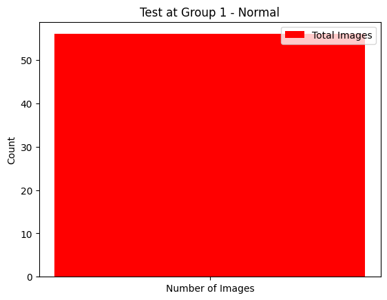

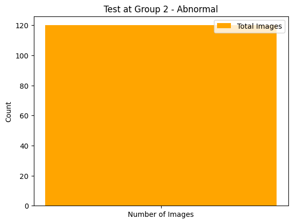

```
DATASET: Train
```

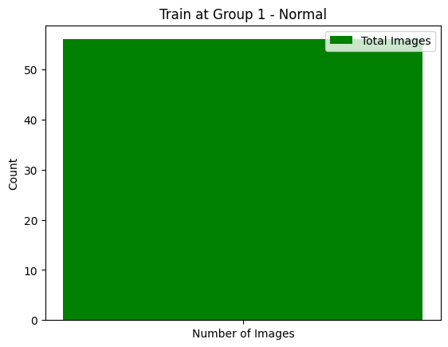

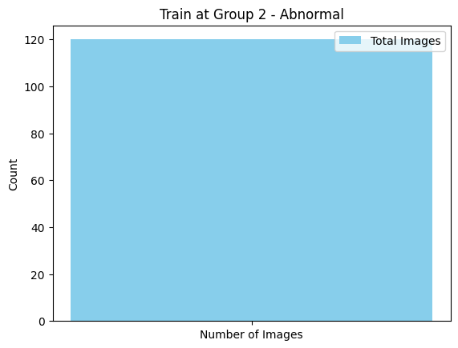

```python
make_image_count_plots(dict_images)
```

```python
%pip install tensorflow
%pip install scikit-learn
%pip install opencv-python
```

# Processamento de Imagem e Extração de ROI (Região de Interesse)

No domínio do pré-processamento de imagens, o nosso foco passa a ser o aumento da relevância das imagens de endoscopia através de um algoritmo meticulosamente concebido. A função extract_roi(), implementada com OpenCV e scikit-learn, lidera esta iniciativa. Operando nos caminhos de ficheiro especificados, a função navega através do conjunto de dados, emparelhando cada imagem original com a sua correspondente máscara de região de interesse (ROI).

O processo envolve a extração de ROIs através da identificação de contornos nas máscaras ROI em tons de cinzento. Utilizando o maior contorno encontrado, o algoritmo calcula a caixa delimitadora e isola com precisão a região de interesse da imagem original. Estas ROIs são depois armazenadas, assegurando uma estrutura de conjunto de dados refinada que satisfaz de forma óptima os requisitos do nosso modelo de deep learning. Os conjuntos resultantes de imagens de treino e teste, juntamente com as respectivas máscaras e labels, estabelecem uma base sólida para o treino subsequente do modelo, validando o nosso compromisso com as metodologias de processamento de dados centradas na imagem.

```python
import cv2
from sklearn.model_selection import train_test_split

def extract_roi(paths):
    train_images = []
    test_images = []
    train_masks = []
    test_masks = []
    train_labels = []
    test_labels = []
    for path in paths:
        for sub_path in os.listdir(paths[path]):
            type_of_data = paths[path].split('\\')[-1]
            for img in os.listdir(paths[path]+"\\"+sub_path):
                # Le a imagem e a mascara
                if not img.endswith("_ROI.png"):
                    img_url = paths[path]+"\\"+sub_path+"\\"+img
                    roi_url = paths[path]+"\\"+sub_path+"\\"+img.split('.')[0]+"_ROI.png"
                    image = cv2.imread(img_url)
                    mask = cv2.imread(roi_url, cv2.IMREAD_GRAYSCALE)

                    # procura os contornos na mascara
                    contours, _ = cv2.findContours(mask, cv2.RETR_EXTERNAL, cv2.CHAIN_APPROX_SIMPLE)

                    # extrai o ROI da imagem utilizando o contorno mais largo
                    if contours:
                        largest_contour = max(contours, key=cv2.contourArea)
                        x, y, w, h = cv2.boundingRect(largest_contour)
                        roi_image = image[y:y + h, x:x + w]
                        roi_mask = mask[y:y + h, x:x + w]
                        # Save the extracted ROI
                        cv2.imwrite(os.path.join(paths[path]+"\\", img), roi_image)
                        cv2.imwrite(os.path.join(paths[path]+"\\", img.split('.')[0]+"_MASK.png"), roi_mask)
                        label = os.path.join(paths[path]+"\\", img).split('_')[1]
                        if path == 'train':
                            train_images.append(os.path.join(paths[path]+"\\", img))
                            train_masks.append(os.path.join(paths[path]+"\\", img.split('.')[0]+"_MASK.png"))
                            train_labels.append(label)
                        else:
                            test_images.append(os.path.join(paths[path]+"\\", img))
                            test_masks.append(os.path.join(paths[path]+"\\", img.split('.')[0]+"_MASK.png"))
                            test_labels.append(label)
    return train_images, test_images, train_masks, test_masks, train_labels, test_labels

images_train, images_test, masks_train, masks_test, labels_train, labels_test = extract_roi(paths)
```

```python
print(str(len(images_train)) +" "+ str(len(labels_train)))
```

```
87 87
```

# Preprocessamento dos dados

Neste capítulo, exploramos as etapas de preprocessamento de dados essenciais para o treino eficaz do modelo de deep learning. Começamos pela instalação de bibliotecas fundamentais, destacando a importância do ambiente TensorFlow com a extensão Keras para simplificar o desenvolvimento de modelos. Em seguida, apresentamos a aplicação do LabelEncoder do Scikit-Learn para converter rótulos de classes em representações numéricas, preparando assim os dados para tarefas de classificação.

A transformação dos rótulos em one-hot encoding é então abordada por meio da poderosa função to_categorical da Keras. Este passo é crucial para representar categorias de maneira binária, aprimorando a capacidade do modelo de compreender e generalizar padrões complexos nos dados. A implementação é exemplificada com um trecho de código que demonstra a conversão eficaz dos rótulos.

Importante a relevância da divisão apropriada do conjunto de dados entre treino e validação. Utilizando a função train_test_split do Scikit-Learn, alcançamos uma distribuição equitativa, proporcionando ao modelo a oportunidade de aprender com uma variedade representativa de dados durante o treino.

```python
%pip install tensorflow.keras
from sklearn.preprocessing import LabelEncoder
import tensorflow as tf

Le = LabelEncoder()
train_image_labels = Le.fit_transform(labels_train)

train_image_labels[:-10]
```

```python
train_image_labels = tf.keras.utils.to_categorical(train_image_labels)

train_image_labels[:10]
```

```
array([[0., 1.],
       [0., 1.],
       [0., 1.],
       [0., 1.],
       [0., 1.],
       [0., 1.],
       [0., 1.],
       [0., 1.],
       [0., 1.],
       [0., 1.]], dtype=float32)
```

```python
from sklearn.model_selection import train_test_split

Train_paths , Val_paths , Train_labels , Val_labels = train_test_split(images_train , train_image_labels)
```

# Preparação do Dataset de imagens

A base de qualquer empreendimento de deep learning bem sucedido é um conjunto de dados meticulosamente preparado, uma sinfonia de curadoria e aumento cuidadosos. Esta secção investiga o intrincado processo de moldar dados de imagem em bruto numa dieta nutritiva para o nosso modelo. A função get_dataset() orquestra este bailado, transformando caminhos e etiquetas de imagens em tensores TensorFlow. À medida que cada par imagem-rótulo faz uma pirueta através da função load(), é efectuada uma mistura harmoniosa de descodificação e redimensionamento, trazendo uniformidade ao conjunto diversificado.

Para infundir resiliência e adaptabilidade no nosso modelo, um trio de técnicas de aumento de dados é o centro das atenções. A inversão horizontal, a rotação aleatória e o zoom dão vida ao conjunto de dados de forma dinâmica, fortalecendo o modelo contra as nuances dos dados do mundo real. A utilização diligente do "AUTOTUNE" do TensorFlow garante uma utilização óptima dos recursos durante esta coreografia.

```python
def load(image , label):
    image = tf.io.read_file(image)
    image = tf.io.decode_png(image , channels = 3)
    return image , label
```

```python
# Definição do tamanho da imagem e do tamanho do grupo/batch
IMG_SIZE = 256
BATCH_SIZE = 32

# Efetuado o redimensionamento de todas as imagens, para o tamanho definido em 'IMG_SIZE'
resize = tf.keras.Sequential([
    tf.keras.layers.experimental.preprocessing.Resizing(IMG_SIZE, IMG_SIZE)
])

# Definição de sequência, com 3 camadas de aumento de dados
data_augmentation = tf.keras.Sequential([
    # Espelhamento horizontal aleatório das imagens
    tf.keras.layers.experimental.preprocessing.RandomFlip("horizontal"),
    # Adicionada uma rotação aleatória às imagens, no intervalo definido
    tf.keras.layers.experimental.preprocessing.RandomRotation(0.2),
    # Aplicação de um zoom aleatório à altura das imagens, no intervalo definido
    tf.keras.layers.experimental.preprocessing.RandomZoom(height_factor = (-0.3, -0.2))
])
```

```python
# Importação da constante 'AUTOTUNE', da biblioteca 'TensorFlow', permitindo que haja um ajuste dinâmico na utilização de recursos
AUTOTUNE = tf.data.experimental.AUTOTUNE
# Definição da função 'get_dataset'
def get_dataset(paths , labels , train = True):
    # Conversão dos "paths" das imagens e das "labels" em tensores 'TensorFlow'
    image_paths = tf.convert_to_tensor(paths)
    labels = tf.convert_to_tensor(labels)

    # Criação de datasets, a partir dos tensores
    image_dataset = tf.data.Dataset.from_tensor_slices(image_paths)
    label_dataset = tf.data.Dataset.from_tensor_slices(labels)

    # Efetuada a combinação dos datasets das imagens e das labels
    dataset = tf.data.Dataset.zip((image_dataset , label_dataset))

    # Aplicação da função 'load' a cada par "imagem-label" no dataset
    dataset = dataset.map(lambda image , label : load(image , label))
    # Redimensionamento das imagens, no dataset, e paralelização do carregamento
    dataset = dataset.map(lambda image, label: (resize(image), label) , num_parallel_calls=AUTOTUNE)
    # Efetuado um 'shuffle' aos elementos do dataset, de forma aleatória
    dataset = dataset.shuffle(1000)
    # Agrupamento dos elementos do dataset, em lotes de tamanho 'BATCH_SIZE'
    dataset = dataset.batch(BATCH_SIZE)

    # Caso seja efetuado o treino, aplicar a função de aumento dos dados ao dataset
    if train:
        dataset = dataset.map(lambda image, label: (data_augmentation(image), label) , num_parallel_calls=AUTOTUNE)
    # Repetir o dataset indefinidamente
    dataset = dataset.repeat()
    # Retornar o dataset final
    return dataset
```

```python
# Medição do tempo de execução da criação do conjunto de dados de treino
%time train_dataset = get_dataset(Train_paths , Train_labels)

# Obtenção do próximo elemento do conjunto de dados, utilizando um iterador
image , label = next(iter(train_dataset))
# Exibição do formato ('shape') da imagem
print(image.shape)
# Exibição do formato ('shape') da label
print(label.shape)
```

```
CPU times: total: 469 ms
Wall time: 446 ms
```

```
(32, 256, 256, 3)
(32, 2)
```

```
Abnormal
```

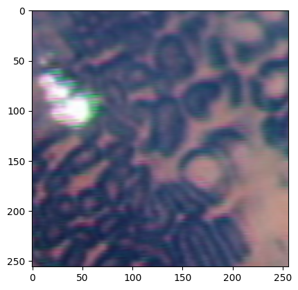

```python
import numpy as np
# Exibição da label prevista, utilizando o método 'inverse_transform' do objeto 'LabelEncoder' (Le)
print(Le.inverse_transform(np.argmax(label , axis = 1))[0])
# Exibição da imagem, utilizando o 'Matplotlib, após normalizar os valores de pixel para o intervalo (0,1)
plt.imshow((image[0].numpy()/255).reshape(256 , 256 , 3))
```

```python
# Medição do tempo de execução para a criação do conjunto de dados de validação
%time val_dataset = get_dataset(Val_paths , Val_labels , train = False)

# Obtenção do próximo elemento do conjunto de dados de validação, utilizando um iterador
image , label = next(iter(val_dataset))
# Exibição do formato ('shape') da imagem
print(image.shape)
# Exibição do formato ('shape') da label
print(label.shape)
```

```
CPU times: total: 31.2 ms
Wall time: 22 ms
(22, 256, 256, 3)
(22, 2)
```

```
Abnormal
```

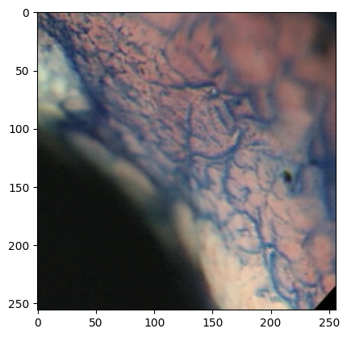

```python
# Exibição da label prevista, utilizando o método 'inverse_transform' do objeto 'LabelEncoder' (Le)
print(Le.inverse_transform(np.argmax(label , axis = 1))[0])
# Exibição da imagem, utilizando o 'Matplotlib, após normalizar os valores de pixel para o intervalo (0,1)
plt.imshow((image[0].numpy()/255).reshape(256 , 256 , 3))
```

# Treino e Arquitetura do Modelo

Na construção do nosso modelo de deep learning, utilizámos a poderosa arquitetura EfficientNetB3 da biblioteca TensorFlow. Essa arquitetura serve como espinha dorsal, permitindo que o modelo capture características complexas em imagens de endoscopia. Configurada com uma forma de entrada de (256, 256, 3) e excluindo a camada totalmente conectada no topo, a arquitetura EfficientNetB3 estabelece as bases para uma classificação de imagem robusta.

No nosso modelo sequencial TensorFlow, a espinha dorsal do EfficientNetB3 está perfeitamente integrada, seguida de uma camada de Global Average Pooling para redução da dimensão espacial. Para melhorar a regularização, é incorporada uma camada de Dropout com uma taxa de 0,3. O toque final é uma camada Dense totalmente conectada com duas unidades, empregando a ativação softmax para classificação categórica.

Para efeitos de transparência, é apresentado um resumo da arquitetura do modelo, incluindo a estrutura por camadas e a contagem dos parâmetros. O modelo é compilado utilizando o optimizador Adam, a função de perda de entropia cruzada categórica e métricas-chave como a exatidão, a precisão e a recuperação para uma avaliação abrangente. Subsequentemente, o processo de formação desenrola-se, aproveitando o conjunto de dados train_dataset e validando-o em relação ao conjunto de dados val_dataset durante dez épocas, com métricas detalhadas e desempenho registado no histórico de formação. Esta combinação estratégica de arquitetura e parâmetros de treino foi meticulosamente concebida para capacitar o modelo para uma deteção precisa e eficiente de metaplasia em imagens de endoscopia.

```python
# Importação da arquitetura 'EfficientNetB3', da biblioteca 'keras.applications'
from tensorflow.keras.applications import EfficientNetB3

# Criação de uma instância do modelo 'EfficientNetB3', com entrada de forma (224, 224, 3), e sem camada, totalmente conectada no topo
backbone = EfficientNetB3(
    input_shape=(256, 256, 3),
    include_top=False
)

# Criação de um modelo sequencial no 'TensorFlow'
model = tf.keras.Sequential([
    # Adicionada uma espinha dorsal 'EfficientNetB3' ao modelo sequencial
    backbone,
    # Adicionada uma camada de pooling global média, para reduzir as dimensões espaciais
    tf.keras.layers.GlobalAveragePooling2D(),
    # Adicionada uma camada de dropout, para regularização
    tf.keras.layers.Dropout(0.3),
    # Adicionada uma camada totalmente conectada (dense), com 4 unidades e ativação 'softmax' para a classificação
    tf.keras.layers.Dense(2, activation='softmax')
])

# Exibição de um resumo do modelo, incluíndo a arquitetura e o número de parâmetros
model.summary()
```

```python
# Compilação do modelo com o otimizador 'Adam', função de perda 'categorical_crossentropy' e métricas de 'accuracy', 'precision' e 'recall'
model.compile(
    optimizer=tf.keras.optimizers.Adam(learning_rate=0.001, beta_1=0.9, beta_2=0.999, epsilon=1e-07),
    loss = 'categorical_crossentropy',
    metrics=['accuracy' , tf.keras.metrics.Precision(name='precision'),tf.keras.metrics.Recall(name='recall')]
)
```

```python
# Exibição de um resumo do modelo compilado
model.summary()
```

```
Model: "sequential_2"
_________________________________________________________________
 Layer (type)                Output Shape              Param #
=================================================================
 efficientnetb3 (Functional  (None, 8, 8, 1536)        10783535
 )

 global_average_pooling2d (  (None, 1536)              0
 GlobalAveragePooling2D)

 dropout (Dropout)           (None, 1536)              0

 dense (Dense)               (None, 2)                 3074

=================================================================
Total params: 10786609 (41.15 MB)
Trainable params: 10699306 (40.81 MB)
Non-trainable params: 87303 (341.03 KB)
_________________________________________________________________
```

```python
# Efetuado o treino ao modelo, utilizando o conjunto de treino, e validando-o, utilizando o conjunto de validação
history = model.fit(
    # Conjunto de treino
    train_dataset,
    # Número de passos, por época
    steps_per_epoch=len(Train_paths)*5//BATCH_SIZE,
    # Número total de épocas
    epochs=10,
    # Conjunto de validação
    validation_data=val_dataset,
    # Número de passos de validação, por época
    validation_steps = len(Val_paths)*5//BATCH_SIZE,
)
```

[output not shown]

# Ajustes ao Modelo

A melhoria contínua e o aperfeiçoamento do nosso modelo de deep learning são essenciais para o seu desempenho. São implementados ajustes e aperfeiçoamentos regulares com base no feedback contínuo e nos resultados da avaliação. Este processo iterativo envolve a otimização de hiperparâmetros, a atualização de conjuntos de dados de treino e a incorporação dos mais recentes avanços nas técnicas de deep learning. Esses ajustes adaptativos contribuem para a resiliência do modelo, garantindo que ele continue a ser uma ferramenta de deteção precisa de metaplasia normal ou não normal em imagens de endoscopia.

```python
model.layers[0].trainable = False
```

```python
checkpoint = tf.keras.callbacks.ModelCheckpoint("best_weights.h5",verbose=1,save_best_only=True,save_weights_only = True)
early_stop = tf.keras.callbacks.EarlyStopping(patience=4)
```

```python
# Exibição de um resumo do modelo compilado
model.summary()
```

```
Model: "sequential_2"
_________________________________________________________________
 Layer (type)                Output Shape              Param #
=================================================================
 efficientnetb3 (Functional  (None, 8, 8, 1536)        10783535
 )

 global_average_pooling2d (  (None, 1536)              0
 GlobalAveragePooling2D)

 dropout (Dropout)           (None, 1536)              0

 dense (Dense)               (None, 2)                 3074

=================================================================
Total params: 10786609 (41.15 MB)
Trainable params: 3074 (12.01 KB)
Non-trainable params: 10783535 (41.14 MB)
_________________________________________________________________
```

```python
# Efetua o treino ao modelo, utilizando o conjunto de treino e validando-o, utilizando o conjunto de validação, incorporando os callbacks
history = model.fit(
    # Conjunto de treino
    train_dataset,
    # Número de passos, por época
    steps_per_epoch=len(Train_paths)*5//BATCH_SIZE,
    # Número total de épocas de treino
    epochs=10,
    # Callbacks para monitorização e aprimoramento do treino
    callbacks=[checkpoint , early_stop],
    # Conjunto de validação
    validation_data=val_dataset,
    # Número de passos de validação, por época
    validation_steps = len(Val_paths)*5//BATCH_SIZE,
)
```

[output not shown]

```python
# Importação da arquitetura 'EfficientNetB3', da biblioteca 'keras.applications'
from tensorflow.keras.applications import EfficientNetB3

# Criação de uma instância do modelo 'EfficientNetB3', com entrada de forma (256, 256, 3),
# e sem camada, totalmente conectada no topo
backbone = EfficientNetB3(
    input_shape=(256, 256, 3),
    include_top=False
)

# Criação de um modelo sequencial no 'TensorFlow'
model = tf.keras.Sequential([
     # Adicionada uma espinha dorsal 'EfficientNetB3' ao modelo sequencial
    backbone,
    # Adicionada uma camada de pooling global média, para reduzir as dimensões espaciais
    tf.keras.layers.GlobalAveragePooling2D(),
    # Adicionada uma camada de dropout, para regularização
    tf.keras.layers.Dropout(0.3),
    # Adicionada uma camada totalmente conectada (dense), com 4 unidades e ativação 'softmax' para a classificação
    tf.keras.layers.Dense(2, activation='softmax')
])

# Compilação do modelo com o otimizador 'Adam', função de perda 'categorical_crossentropy' e métricas de 'accuracy', 'precision' e 'recall'
model.compile(
    optimizer=tf.keras.optimizers.Adam(learning_rate=0.001, beta_1=0.9, beta_2=0.999, epsilon=1e-07),
    loss = 'categorical_crossentropy',
    metrics=['accuracy' , tf.keras.metrics.Precision(name='precision'),tf.keras.metrics.Recall(name='recall')]
)
```

```python
model.load_weights("best_weights.h5")
```

```python
# Obtenção dos "paths" das imagens de teste
test_image_paths = images_test
# Obtenção das labels das imagens de teste, utilizando a função 'get_label'
test_labels = labels_test

# Conversão das labels, para a representação numérica, utilizando o 'LabelEncoder' (Le)
test_labels = Le.transform(test_labels)
# Conversão das labels, para representação "one-hot encoding"
test_labels = tf.keras.utils.to_categorical(test_labels)

# Conversão dos "paths" das imagens e das labels para tensores 'TensorFlow'
test_image_paths = tf.convert_to_tensor(test_image_paths)
test_labels = tf.convert_to_tensor(test_labels)

# Função para descodificar as imagens
def decode_image(image , label):
    image = tf.io.read_file(image)
    image = tf.io.decode_jpeg(image , channels = 3)
    image = tf.image.resize(image , [256 , 256] , method="bilinear")
    return image , label

# Criação de um conjunto de dados de teste, utilizando o "TensorFlow Dataset API"
test_dataset = (
     tf.data.Dataset
    .from_tensor_slices((test_image_paths, test_labels))
    .map(decode_image)
    .batch(BATCH_SIZE)
)
```

```python
# Obtenção do próximo lote de imagens e labels do conjunto de dados de teste
image , label = next(iter(test_dataset))
# Exibição do formato ('shape') da imagem
print(image.shape)
# Exibição do formato ('shape') da label
print(label.shape)
```

```
(32, 256, 256, 3)
(32, 2)
```

```
Normal
```

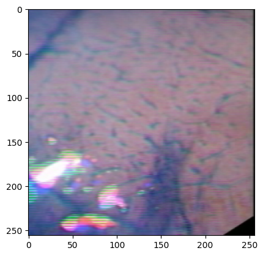

```python
# Exibição da label prevista, utilizando o método 'inverse_transform' do objeto 'LabelEncoder' (Le)
print(Le.inverse_transform(np.argmax(label , axis = 1))[0])
# Exibição da imagem, utilizando o 'Matplotlib, após normalizar os valores de pixel para o intervalo (0,1)
plt.imshow((image[0].numpy()/255).reshape(256 , 256 , 3))
```

# Avaliação e Previsão do Modelo

```python
from sklearn.metrics import classification_report
from sklearn.metrics import accuracy_score
# Assumindo que as test_labels são as labels verdadeiras para o set de testes
predictions = model.predict(test_dataset)
predicted_labels = (predictions > 0.5).astype('int')  #  Binary classification threshold
accuracy = accuracy_score(test_labels, predicted_labels)
print(classification_report(test_labels, predicted_labels))
print(f"Accuracy: {accuracy:.2%}")
```

```
              precision    recall  f1-score   support

           0       0.86      0.62      0.72        60
           1       0.49      0.79      0.60        28

   micro avg       0.67      0.67      0.67        88
   macro avg       0.67      0.70      0.66        88
weighted avg       0.74      0.67      0.68        88
 samples avg       0.67      0.67      0.67        88

Accuracy: 67.05%
```

```python
# Carregamento e exibição de uma imagem
def LoadImage(image_path):
    print(image_path)
    # Leitura do "path" da imagem
    image = tf.io.read_file(image_path)
    # Descodificação da imagem, utilizando o formato ".jpeg" com 3 canais de côr (RGB)
    image_type = image_path.split('.')[1]
    list_jpeg = ["JPG","jpg", "JPEG", "jpeg"]
    list_png = ["PNG", "png"]
    if image_type in list_jpeg:
        image = tf.io.decode_jpeg(image , channels = 3)
    if image_type in list_png:
         image = tf.io.decode_png(image , channels = 3)
    # Redimensionamento da imagem, para as dimensões desejadas, utilizando o método bilinear
    image = tf.image.resize(image , [256 , 256] , method="bilinear")
    # Exibição da imagem, utilizando o 'Matplotlib'
    plt.imshow(image.numpy()/255)
    # Adicionada uma dimensão adicional para corresponder à entrada esperada do modelo
    image = tf.expand_dims(image , 0)
    return image

# Função para efetuar as previsões em tempo real
def RealtimePrediction(image_path , model, encoder_):
    # Carregamento da imagem, utilizando a função 'LoadImage'
    image = LoadImage(image_path)
    # Realização da previsão, utilizando o modelo
    prediction = model.predict(image)
    # Obtenção do índice da classe de previsão com maior probabilidade
    prediction = np.argmax(prediction , axis = 1)
    # Inversão da transformação aplicada anteriormente às labels, utilizando o objeto 'encoder_'
    return encoder_.inverse_transform(prediction)[0]
```

# Previsão em tempo-real

```
testeImagemYoutubeAbnormal.jpg
```

```
'Abnormal'
```

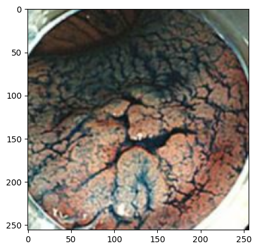

```python
RealtimePrediction("testeImagemYoutubeAbnormal.jpg", model, Le)
```

# Conclusão

Na sinfonia de píxeis e algoritmos, a nossa viagem pelos domínios da classificação da metaplasia em imagens de endoscopia termina, deixando para trás um rasto de conhecimentos e realizações. Desde o batimento cardíaco vibrante da GPU até à extração meticulosa de Regiões de Interesse (ROI), cada passo do nosso projeto desvendou desafios únicos com a proeza da deep learning. O modelo, adornado com a arquitetura EfficientNetB3, passou por uma fase de formação transformadora, refinando as suas capacidades para discernir padrões e nuances subtis no conjunto de dados.

A preparação do conjunto de dados de imagens surgiu como um prelúdio crucial, entrelaçando arte e ciência na criação de um ambiente nutritivo para o modelo aprender e se adaptar. As técnicas de aumento e a remodelação cuidadosa das imagens, semelhante ao toque de um escultor magistral, fortificaram o nosso conjunto de dados, incutindo resiliência contra as variações imprevisíveis dos dados do mundo real.

A nossa incursão no território inexplorado da classificação Metaplasia não só iluminou o potencial da aprendizagem profunda, como também sublinhou a necessidade de aperfeiçoamento e exploração contínuos. Na grande tapeçaria dos avanços médicos, o nosso projeto é um testemunho do casamento entre a tecnologia de ponta e a procura de melhores resultados nos cuidados de saúde. A viagem pode ter chegado ao fim, mas os ecos do seu impacto ressoam muito para além disso, chamando-nos para novas fronteiras no cenário em constante evolução da IA nos cuidados de saúde.

## Referências

Fortun, P. J., Anagnostopoulos, G. K., Kaye, P., James, M., Foley, S., Samuel, S., Shonde, A., Badreldin, R., Campbell, E., Hawkey, C. J., & Ragunath, K. (2006). Acetic acid‐enhanced magnification endoscopy in the diagnosis of specialized intestinal metaplasia, dysplasia and early cancer in Barrett’s oesophagus. Alimentary Pharmacology & Therapeutics, 23(6), 735–742. https://doi.org/10.1111/j.1365-2036.2006.02823.x

Kirtane, T., & Parasa, S. (2023). The Role of Artificial Intelligence in Surveillance in Barrett’s Esophagus and Gastric Intestinal Metaplasia. Foregut: The Journal of the American Foregut Society, 3(1), 121–127. https://doi.org/10.1177/26345161231151947

Lin, N., Yu, T., Zheng, W., Hu, H., Xiang, L., Ye, G., Zhong, X., Ye, B., Wang, R., Deng, W., Li, J., Wang, X., Han, F., Zhuang, K., Zhang, D., Xu, H., Ding, J., Zhang, X., Shen, Y., … Si, J. (2021). Simultaneous Recognition of Atrophic Gastritis and Intestinal Metaplasia on White Light Endoscopic Images Based on Convolutional Neural Networks: A Multicenter Study. Clinical and Translational Gastroenterology, 12(8), e00385. https://doi.org/10.14309/ctg.0000000000000385

Sousa, A., Dinis-Ribeiro, M., Areia, M., & Coimbra, M. (2009). IDentifying cancer regions in vital-stained magnification endoscopy images using adapted color histograms. 2009 16th IEEE International Conference on Image Processing (ICIP), 681–684. https://doi.org/10.1109/ICIP.2009.5414082